# DATA-413/613 HW 01

Author

Ana Miranda

Published

September 1, 2026

# Admin Elements

Review the Syllabus on Canvas and answer the following questions:

I, *Ana Miranda* have:

1. Ensured my Canvas Profile has a photo of me (head and shoulders).
2. Reviewed the syllabus and the associated policies on the following date: 09/10/2024.
3. Reviewed the American University policies on academic integrity and I agree to comply with them and the additional guidance in the syllabus for this course.
4. Reviewed the General Instructions for Assignments on the following date: 09/10/2024.
5. Confirmed my information in the Student Info spreadsheet on Canvas Collaborations is correct.
6. Updated my version of R and RStudio and the {tidyverse} packages for this course.

# Analysis Elements

0. Load the {tidyverse} and use functions from {tidyverse} when possible.

```r
#| eval: true
#| message: false

suppressMessages(library(tidyverse))
library(ggthemes)
library(broom)
library(knitr)
library(forcats)
```

# 1 College Scorecard

The data folder contains `college_scorecard_extract_2024-06-13_UG.csv`, a *subset* of data in the [College Scorecard](https://collegescorecard.ed.gov/data/) as of June 13, 2024. This data set contains information on undergraduate college cohorts in the United States. The data dictionary is in the `data` folder. The variables include: (see HTML file)

1. Load the data.
1. Load `college_scorecard_extract_2024-06-13_UG.csv` (in the `data` directory) using one call to a {readr} function with a relative path and save the resulting tibble.
   - Note, this data uses “NULL” for some missing values. Use an argument of the {readr} function to convert “NULL” to `NA` during the loading of the data. Do not not suppress messages or warnings.

```r
coll_scorecd <- read_csv("../data/college_scorecard_extract_2024-06-13_413.csv", na = "NULL")
```

2. Use `glimpse()` to examine the data.

```r
glimpse(coll_scorecd)
```

```
Rows: 3,059
Columns: 48
$ ADM_RATE        <dbl> 0.7160, 0.8854, 0.7367, 0.9799, 0.7890, NA, NA, 0.9680…
$ AGE_ENTRY       <dbl> 20.28374, 23.60797, 22.72792, 20.13099, 21.13770, 23.0…
$ AVGFACSAL       <dbl> 8779, 11590, 9820, 7701, 10509, 6523, 8834, 7885, 1109…
$ CITY            <chr> "Normal", "Birmingham", "Huntsville", "Montgomery", "T…
$ CONTROL         <dbl> 1, 1, 1, 1, 1, 1, 1, 1, 1, 2, 1, 1, 1, 2, 1, 1, 1, 1, …
$ COSTT4_A        <dbl> 21924, 26248, 24869, 21938, 31050, 13930, NA, 20621, 3…
$ ENDOWBEGIN      <dbl> NA, 539858544, 75837207, 111315175, 939393269, 433325,…
$ FEMALE          <chr> "0.5640301318", "0.6390907397", "0.4763499372", "0.613…
$ FIRST_GEN       <chr> "0.3658280922", "0.341223671", "0.3101321586", "0.3434…
$ GRAD_DEBT_MDN   <chr> "31000", "22300", "20705", "31000", "22750", "9766", "…
$ HBCU            <dbl> 1, 0, 0, 1, 0, 0, 0, 0, 0, 0, 0, 0, 0, 0, 1, 0, 0, 0, …
$ HSI             <dbl> 0, 0, 0, 0, 0, 0, 0, 0, 0, 0, 0, 0, 0, 0, 0, 0, 0, 0, …
$ ICLEVEL         <dbl> 1, 1, 1, 1, 1, 2, 1, 1, 1, 1, 2, 2, 2, 1, 2, 2, 2, 2, …
```

[output cut: 35 more lines]

2. If you used the default settings for reading in the data, multiple variables are probably type/class character when the data suggests they should be numeric.
1. Which ones are they?

```r
spec(coll_scorecd)
```

[output not shown]

2. Look at the data. Why were these columns read in as type character instead of double?
- **Answer:** Because the data import parsing algorithm identified cells containing characters and assumed such columns as “character” data types and not as “numeric/double”. That is because “NULL” is not the only code used to identify NA’s. The code “PrivacySuppressed” appears through out the data and I’m also assuming that information to be NA as well. Next step, read the data again including “PrivacySuppressed” values as NA to fix the problem.
3. Reload the data with a {readr} function and use an argument to convert the offending entries to `NA` so the variables are automatically read in as type double. You should have 42 variables of type double.

```r
coll_scorecd2 <- read_csv("../data/college_scorecard_extract_2024-06-13_413.csv",
                          col_names = TRUE,
                          na = c("NULL", "PrivacySuppressed"))
```

4. How is average faculty salary associated with the median earnings of working students ten years after initial enrollment?
1. Use {ggplot2} to create an appropriate plot to assess for a relationship (with `AVGFACSAL` as the explanatory X variable). Use a {ggplot2} function argument to reduce over-plotting . Add the default smoother with `se = FALSE`. Facet on `ICLEVEL`.

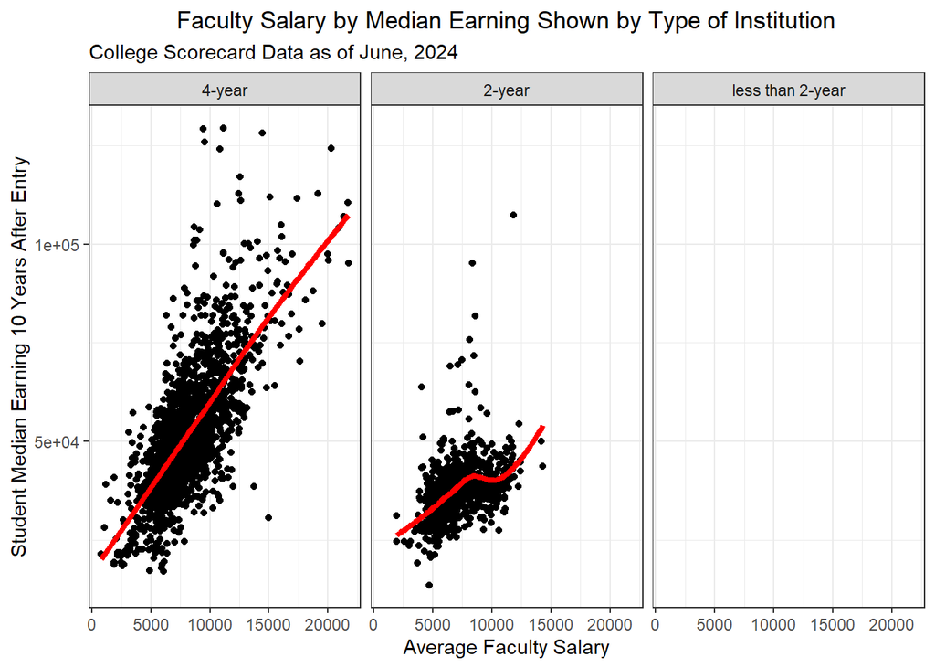

```r
ICLEVEL_N <- c("4-year", "2-year", "less than 2-year")
names(ICLEVEL_N) <- c(1, 2, 3)

coll_scorecd2 %>%
  ggplot(mapping = aes(x = AVGFACSAL,
                       y = MD_EARN_WNE_P10
                       )) +
    geom_point() +

    geom_smooth(se = FALSE, linetype = "solid", linewidth = 1.5, colour = "red") +
    facet_wrap( ~ ICLEVEL, labeller = labeller(ICLEVEL = ICLEVEL_N)) +
    theme_bw() +

    xlab("Average Faculty Salary") +
    ylab("Student Median Earning 10 Years After Entry") +
    ggtitle(label = "Faculty Salary by Median Earning Shown by Type of Institution",
            subtitle = "College Scorecard Data as of June, 2024") +
    theme(plot.title = element_text(hjust = 0.5))
```

2. Interpret the plots about the potential relationships.
- **Answer:** The plots indicate a strong positive relationship between faculty salary and potential student salary, specially for 4-year programs.
3. Why did `geom_smooth()` chose the `mgcv::gam()` smoothing method.
- **Answer:** Because it must be the default choice of smoothing function for the data at hand when no specific one was chosen a priory. Following is what R documentation states: “For method = NULL the smoothing method is chosen based on the size of the largest group (across all panels). stats::loess() is used for less than 1,000 observations; otherwise mgcv::gam() is used with formula = y ~ s(x, bs =”cs”) with method = “REML”.”
4. Why is there no `ICLEVEL` 3 plot, or, if there is a plot, why is there no data in the `ICLEVEL` 3 plot?

```r
coll_scorecd2 %>%
  select(ICLEVEL, AVGFACSAL, MD_EARN_WNE_P10) %>%
  group_by(ICLEVEL) %>%
  summarize(count = n(),
            sum_AVGFACSAL = sum(AVGFACSAL, na.rm = TRUE),
            sum_MD_EARN_WNE_P10 = sum(MD_EARN_WNE_P10, na.rm = TRUE),
            .groups = "drop")
```

```
# A tibble: 3 × 4
  ICLEVEL count sum_AVGFACSAL sum_MD_EARN_WNE_P10
    <dbl> <int>         <dbl>               <dbl>
1       1  1961      15574784            96666063
2       2   973       6233201            35021804
3       3   125             0             3877464
```

- **Answer:** There are 125 observations in the data for institution level 3, or less than 2-year programs. However, the data for average faculty salary is missing for level 3 institutions. Therefore, those observations were dropped from the plot above.
5. Use `lm()` to run a linear model of the relationship **for only those schools with ICLEVEL 1** and save the results.

```r
coll_scorecd2 %>%
  filter(ICLEVEL == 1) -> data_lv1

lm_model = lm(data = data_lv1, formula = log(MD_EARN_WNE_P10) ~ log(AVGFACSAL))
```

6. Use `summary()` on the results.

```r
summary(lm_model)
```

```
Call:
lm(formula = log(MD_EARN_WNE_P10) ~ log(AVGFACSAL), data = data_lv1)

Residuals:
     Min       1Q   Median       3Q      Max
-0.91662 -0.12162 -0.00473  0.12420  0.96096

Coefficients:
               Estimate Std. Error t value Pr(>|t|)
(Intercept)     5.13420    0.12658   40.56   <2e-16 ***
log(AVGFACSAL)  0.63449    0.01414   44.86   <2e-16 ***
---
Signif. codes:  0 '***' 0.001 '**' 0.01 '*' 0.05 '.' 0.1 ' ' 1

Residual standard error: 0.2067 on 1861 degrees of freedom
  (98 observations deleted due to missingness)
Multiple R-squared:  0.5196,    Adjusted R-squared:  0.5193
F-statistic:  2013 on 1 and 1861 DF,  p-value: < 2.2e-16
```

7. Interpret the results of the model based on the coefficient for `AVGFACSAL` and the model $p$-value and adjusted $r$-squared value.
- **Answer:** The model is a good fit to predict median earnings 10 year after enrollment with a p-value less than 5%. The intercept is positive and also highly significant with a very small p-value. The coefficient of average faculty salary is positive and also highly significant - indicating that a increase in faculty salary will impact positively student earnings. The R-Squared=0.5196 indicates that this model can predict about 52% of median earning for working students 10 years after enrollment.
8. Given the adjusted $r$-squared value, what do you recommend to try to better predict average earnings of working students ten years after initial enrollment at ICLEVEL 1 schools?
- **Answer:** Adding more variables to the model might improve the model predictability.
5. How is the level of the institution associated with the median earnings of students ten years after enrollment?
1. Reproduce the following plot to explore this relationship. Use `ggthemes::theme_fivethirtyeight()`. Use a chunk option to set the figure width at 7.

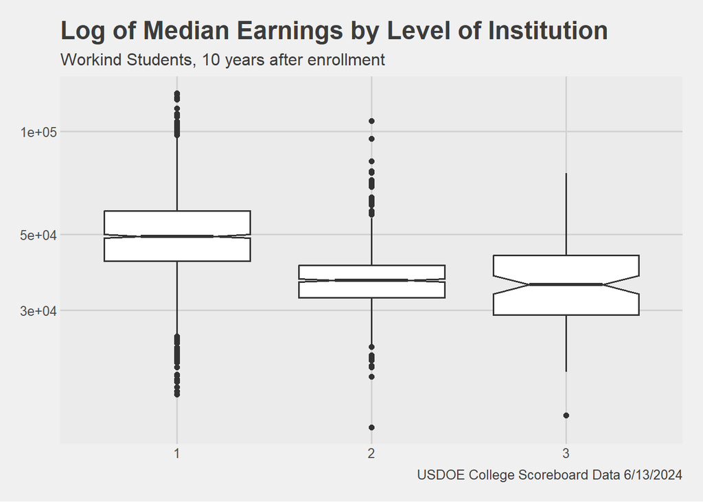

```r
ggplot(coll_scorecd2, mapping = aes(x = as.factor(ICLEVEL),
                                    y = MD_EARN_WNE_P10)) +
geom_boxplot(notch = TRUE) +

scale_y_log10() +

scale_color_fivethirtyeight() +
theme_fivethirtyeight() +

xlab("") +
ylab("") +

ggtitle(label = "Log of Median Earnings by Level of Institution",
        subtitle = "Workind Students, 10 years after enrollment") +

labs(caption = "USDOE College Scoreboard Data 6/13/2024")
```

2. Interpret the plot to answer the question.
- **Answer:** The plot shows that the distribution of average earnings is higher for 4-year institutions.
3. Use `aov()` to test if all of the institution levels have the same true mean of logged median earnings of working students ten years after enrollment.

```r
aov_results = aov(data = coll_scorecd2, log(MD_EARN_WNE_P10) ~ ICLEVEL)
```

4. Use `broom::tidy()` to show the results. Interpret the results

```r
aov_results %>%
  tidy() %>%
  dplyr::mutate_if(is.numeric, funs(as.character(signif(., 3))))
```

```
# A tibble: 2 × 6
  term      df    sumsq meansq statistic p.value
  <chr>     <chr> <chr> <chr>  <chr>     <chr>
1 ICLEVEL   1     56.1  56.1   755       5.4e-148
2 Residuals 2910  216   0.0743 <NA>      <NA>
```

- **Answer:** The ANOVA test (p-value = 5.4e-148) suggests that the true mean of logged median earnings of working students ten years after enrollment are indeed different from level to level.
5. Why would we look at the log of mean earnings instead of the un-logged values?
- **Answer:** Because taking the log of a variable can help to normalize the distribution of the variable and, therefore, make it more suitable/readable for plotting and running analysis.
6. Median Earnings and Percentage of Women Undergraduates
1. Create the following plot as close as you can.

[figure not shown]

```r
  ggplot(coll_scorecd2, mapping = aes(x = UGDS_WOMEN,
                                      y = MD_EARN_WNE_P10
                                     )) +
    geom_point(alpha = 0.3) +

    scale_y_log10() +

    geom_smooth(se = FALSE, linetype = "solid", linewidth = 1.0, colour = "blue") +

    geom_smooth(se = FALSE, method = lm, linetype = "dashed", linewidth = 1.0, colour = "blue") +

    xlab("Percentage Enrollment of Women Undergraduates") +
    ylab("Log (10) of Median Earnings") +

    ggtitle(label = "Log of Median Earnings by Percentage of Women Undergraduates",
          subtitle = "10 years after enrollment at Level 1 institutions") +

    labs(caption = "USDOE College Scoreboard Data 6/13/2024") +
    theme(plot.title = element_text(hjust = 0.5),
          plot.subtitle = element_text(size = 10, hjust = 0.5)
        )
```

2. Pose the question you think the plot might answer and interpret the plot to answer the question. What are the implications for school administrators or for applicants?
- **Answer:** How is median earnings related to percentage of women undergraduates?
- **Answer:** The plot above shows that most data is clustered at about 60 percent of women enrollment and that earnings is also at an average mark. It doesn’t show a very clear relationship.
3. Show the `INSTNM`, `INSTURL`, `RELAFFIL`, and `UGDS_WOMEN` for only schools with either 0% or 100% for `UGDS_WOMEN` sorted by ascending `UGDS_WOMEN` then `INSTNM`. There should be 39 schools. What do you notice?
   - Note: `RELAFFIL` of 30 is Roman Catholic, 66 is Presbyterian Church (USA), 71 is United Methodist, and 80 is Jewish. INSTNM: Institution name INSTURL: URL for institution’s homepage RELAFFIL: Religious affiliation of the institution UGDS_WOMEN: Percent of female undergraduates

```r
coll_scorecd2 %>%
#  filter(!is.na(RELAFFIL)) %>%
  select(INSTNM, INSTURL, RELAFFIL, UGDS_WOMEN) %>%
  filter(UGDS_WOMEN == 0, UGDS_WOMEN == 1) %>%
  arrange(UGDS_WOMEN, INSTNM)
```

```
# A tibble: 0 × 4
# ℹ 4 variables: INSTNM <chr>, INSTURL <chr>, RELAFFIL <dbl>, UGDS_WOMEN <dbl>
```

[figure not shown]

```r
coll_scorecd2 %>%
  filter(UGDS_WOMEN > 0.1 & UGDS_WOMEN < 0.9) %>%

  ggplot(mapping = aes(x = UGDS_WOMEN,
                       y = MD_EARN_WNE_P10
                       )) +
    geom_point(alpha = 0.3) +

    scale_y_log10() +

    geom_smooth(se = FALSE, linetype = "solid", linewidth = 1.0, colour = "blue") +

   geom_smooth(se = FALSE, method = lm, linetype = "dashed", linewidth = 1.0, colour = "blue") +

    xlab("Percentage Enrollment Women Undergraduates") +
    ylab("Log(10) Median Earnings") +

    ggtitle(label = "Log of Median Earnings by Percentage of Women Undergraduates",
          subtitle = "10 years after enrollment at Level 1 institutions with between 10% and 90% women students") +

    labs(caption = "USDOE College Scoreboard Data 6/13/2024") +
    theme(plot.title = element_text(hjust = 0.5))
```

5. What do you notice? What questions does this plot raise for you?
- **Answer:** A slight negative linear association between median earnings and percentage of women undergraduates.
6. Filter out the schools with `UGDS_WOMEN` less than 10% or greater than 90% and use `lm()` to run a linear model and use `summary()` on the results

```r
coll_scorecd2 %>%
  filter(UGDS_WOMEN > 0.1 & UGDS_WOMEN < 0.9) -> coll_scorecd2_W10to90

lm_model2 = lm(data = coll_scorecd2_W10to90, formula = log(MD_EARN_WNE_P10) ~ UGDS_WOMEN)

summary(lm_model2)
```

```
Call:
lm(formula = log(MD_EARN_WNE_P10) ~ UGDS_WOMEN, data = coll_scorecd2_W10to90)

Residuals:
    Min      1Q  Median      3Q     Max
-1.1320 -0.1914 -0.0238  0.1845  1.1382

Coefficients:
            Estimate Std. Error t value Pr(>|t|)
(Intercept) 10.88454    0.02876 378.524  < 2e-16 ***
UGDS_WOMEN  -0.31742    0.04816  -6.591 5.21e-11 ***
---
Signif. codes:  0 '***' 0.001 '**' 0.01 '*' 0.05 '.' 0.1 ' ' 1

Residual standard error: 0.3006 on 2803 degrees of freedom
  (108 observations deleted due to missingness)
Multiple R-squared:  0.01526,   Adjusted R-squared:  0.01491
F-statistic: 43.44 on 1 and 2803 DF,  p-value: 5.208e-11
```

```r
coll_scorecd2 %>%
  filter(ICLEVEL == 1) %>%
  select(ICLEVEL, MD_EARN_WNE_P10, UGDS_AIAN, UGDS_ASIAN, UGDS_BLACK, UGDS_HISP, UGDS_NHPI, UGDS_WHITE) %>%
  pivot_longer(cols = c(UGDS_AIAN, UGDS_ASIAN, UGDS_BLACK, UGDS_HISP, UGDS_NHPI, UGDS_WHITE),
               names_to = "Race",
               values_to = "Race_Percent",
               names_prefix = "UGDS_") -> question7_data


question7_data %>%
  mutate(race_fct = fct_recode(Race, "American Indian/Alaska Native" = "AIAN",
                                     "Asian" = "ASIAN",
                                     "Black" = "BLACK",
                                     "Hispanic" = "HISP",
                                     "Native Hawaiian/Pacific Islander" = "NHPI",
                                     "White" = "WHITE")
         ) -> question7_data2
glimpse(question7_data2)
```

```
Rows: 11,766
Columns: 5
$ ICLEVEL         <dbl> 1, 1, 1, 1, 1, 1, 1, 1, 1, 1, 1, 1, 1, 1, 1, 1, 1, 1, …
$ MD_EARN_WNE_P10 <dbl> 39059, 39059, 39059, 39059, 39059, 39059, 50907, 50907…
$ Race            <chr> "AIAN", "ASIAN", "BLACK", "HISP", "NHPI", "WHITE", "AI…
$ Race_Percent    <dbl> 0.0027, 0.0014, 0.8978, 0.0114, 0.0010, 0.0184, 0.0021…
$ race_fct        <fct> American Indian/Alaska Native, Asian, Black, Hispanic,…
```

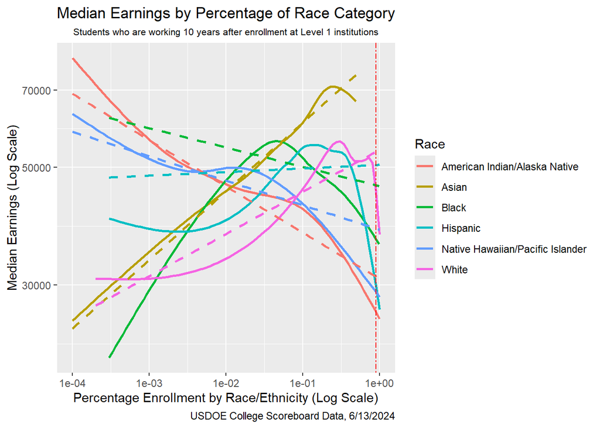

```r
question7_data2 %>%
  ggplot(mapping = aes(x = Race_Percent,
                       y = MD_EARN_WNE_P10,
                       color = race_fct)) +

  scale_x_log10() +
  scale_y_log10() +

  geom_smooth(se = FALSE) +
  geom_smooth(se = FALSE, method = lm, linetype = "dashed") +
  geom_vline(xintercept = .90, color = "red", lty = 6) +

  xlab("Percentage Enrollment by Race/Ethnicity (Log Scale)") +
  ylab("Median Earnings (Log Scale)") +

  ggtitle(label = "Median Earnings by Percentage of Race Category",
          subtitle = "Students who are working 10 years after enrollment at Level 1 institutions") +

  labs(colour = "Race", caption = "USDOE College Scoreboard Data, 6/13/2024") +
  theme(plot.title = element_text(hjust = 0.5),
        plot.subtitle = element_text(size = 8, hjust = 0.5)
        )
```

2. Pose the question you think the plot might answer and interpret the plot to answer the question.
- **Answer:** How does race affect median earnings ten years after enrollment?
- **Answer:** The plot shows that percentage of enrollment by race does seem to have an impact, either positive or negative, on median earnings 10 years after enrollment. For instance, institutions with a low enrollment percentage of American Indians or Alaska Native seem to have students with higher median earnings in the future and vice-versa. Also, Institutions with higher percentages of Asian enrollment, seem to have higher median earnings in the future.
3. What are the ethical implications of using either the linear smoother or the non-linear smoother in these plots to “prove a point”? Which would you recommend and why?
- **Answer:** The non-linear smoother can be more harsh on the interpretation of the plot since it follows the data distribution without making an over consideration. The linear smoother takes into consideration the variability of the data distribution and, therefore, seems to be more appropriate for studying and interpreting the results.
- **Answer:** I would recommend the linear smoother model.
8. Rankings Based on Student Debt and Annual Cost to Attend (Debt/Cost Ratio (DCR))
1. Filter the data to only l`ICLEVEL` 1 with no `NA`s for `COSTT4_A` or `GRAD_DEBT_MDN`. Also remove any satellite campuses using `filter(str_detect(OPEID, "......00"))`. That should leave 1,701 rows.
2. Add a variable called `DCR` based on the ratio of median earnings 10 years after enrollment to median graduation debt at graduation.
3. Use a {dplyr} integer ranking function to compute a ranking using `DCR`. Break any ties using the smallest value and leaving a gap to the next untied DCR such that if two schools are tied for 4th, they are each ranked 4 and the next school is 6. This is similar to many sports rankings.

```r
coll_scorecd2 %>%
  filter(ICLEVEL == 1 & !is.na(COSTT4_A) & !is.na(GRAD_DEBT_MDN)) %>%
  filter(str_detect(OPEID, "......00")) %>%
  mutate(DCR = MD_EARN_WNE_P10/GRAD_DEBT_MDN, DCR_rank = min_rank(DCR)) -> question8_data
glimpse(question8_data)
```

```
Rows: 1,701
Columns: 50
$ ADM_RATE        <dbl> 0.7160, 0.8854, 0.7367, 0.9799, 0.7890, 0.9680, 0.7118…
$ AGE_ENTRY       <dbl> 20.28374, 23.60797, 22.72792, 20.13099, 21.13770, 22.1…
$ AVGFACSAL       <dbl> 8779, 11590, 9820, 7701, 10509, 7885, 11093, 7636, 627…
$ CITY            <chr> "Normal", "Birmingham", "Huntsville", "Montgomery", "T…
$ CONTROL         <dbl> 1, 1, 1, 1, 1, 1, 1, 2, 2, 2, 1, 1, 2, 2, 1, 1, 2, 2, …
$ COSTT4_A        <dbl> 21924, 26248, 24869, 21938, 31050, 20621, 32678, 33920…
$ ENDOWBEGIN      <dbl> NA, 539858544, 75837207, 111315175, 939393269, 5211378…
$ FEMALE          <dbl> 0.5640301, 0.6390907, 0.4763499, 0.6134185, 0.6152524,…
$ FIRST_GEN       <dbl> 0.3658281, 0.3412237, 0.3101322, 0.3434343, 0.2257127,…
$ GRAD_DEBT_MDN   <dbl> 31000, 22300, 20705, 31000, 22750, 25000, 21000, 25000…
$ HBCU            <dbl> 1, 0, 0, 1, 0, 0, 0, 0, 0, 0, 0, 0, 1, 0, 0, 0, 1, 0, …
$ HSI             <dbl> 0, 0, 0, 0, 0, 0, 0, 0, 0, 0, 0, 0, 0, 0, 0, 0, 0, 0, …
$ ICLEVEL         <dbl> 1, 1, 1, 1, 1, 1, 1, 1, 1, 1, 1, 1, 1, 1, 1, 1, 1, 1, …
```

[output cut: 37 more lines]

4. Identify the top 5 best (lowest DCR should be rank value 1) and the bottom 5 worst (largest DCR should have largest rank number). Show only the rank, name, DCR, cost to attend, median debt at graduation, and median earnings 10 years after enrollment.

```r
question8_data %>%
  slice_min(DCR_rank, n=5) %>%
  select(INSTNM, DCR_rank, DCR, COSTT4_A, GRAD_DEBT_MDN, MD_EARN_WNE_P10) -> question8_data_best

question8_data %>%
  slice_max(DCR_rank, n=5) %>%
  select(INSTNM, DCR_rank, DCR, COSTT4_A, GRAD_DEBT_MDN, MD_EARN_WNE_P10) -> question8_data_worst

best_worst_coll = rbind(question8_data_best, question8_data_worst)
best_worst_coll
```

```
# A tibble: 10 × 6
   INSTNM                 DCR_rank    DCR COSTT4_A GRAD_DEBT_MDN MD_EARN_WNE_P10
   <chr>                     <int>  <dbl>    <dbl>         <dbl>           <dbl>
 1 Martin University             1  0.617    25074         42002           25915
 2 Allen University              2  0.799    25002         34290           27399
 3 Morris College                3  0.880    22686         31400           27620
 4 Clinton College               4  0.891    13457         28987           25833
 5 Manhattan School of M…        5  0.911    71175         26994           24590
 6 Berea College              1678 11.3      55656          3591           40738
 7 Laredo College             1677 11.3      11346          2959           33540
 8 Princeton University       1676 10.7      68044         10320          110433
 9 United States Merchan…     1675  9.45      9715          8833           83499
10 San Diego Mesa College     1674  9.10     12900          4725           43015
```

5. What is American University’s rank and DCR? Show only the rank, name, DCR, cost to attend, median debt at graduation, and median earnings 10 years after enrollment.

```r
question8_data %>%
  filter(INSTNM == "American University") %>%
  select(INSTNM, DCR_rank, DCR, COSTT4_A, GRAD_DEBT_MDN, MD_EARN_WNE_P10)
```

```
# A tibble: 1 × 6
  INSTNM              DCR_rank   DCR COSTT4_A GRAD_DEBT_MDN MD_EARN_WNE_P10
  <chr>                  <int> <dbl>    <dbl>         <dbl>           <dbl>
1 American University     1349  3.31    56065         22750           75354
```

# 2 World Bank Data

The World Bank provides loans to countries with the goal of reducing poverty. The data frames in the data folder were taken from the public data repositories of the [World Bank Group DataBank](https://databank.worldbank.org/home). The fertility, life expectancy, and population data are from its [World Development Indicators (WDI)](https://databank.worldbank.org/source/world-development-indicators) as of 1 August 2024.

- `wb_country_income_classification_2023.csv`: Contains information on the countries in the data set. Also includes totals for the regions (sets of countries) and the world. Source is [World Bank Country and Lending Groups](https://datahelpdesk.worldbank.org/knowledgebase/articles/906519-world-bank-country-and-lending-groups). The variables are: see HTML file
1. Use a relative path and a {readr} function to load each of these four files into its own tibble. *Be sure to look at the data after loading to ensure it loaded as expected, without problems, and fix any problems using {readr} function arguments.* Consider using the `problems()` function to identify the locations of any problems.
   - Note: `wb_country_income_classification_2023` has a row of all `NA`s between the countries and the collective economies such as regions. The argument `skip_empty_rows` defaults to `TRUE` but, since there are commas in the file, the row is not counted as “empty.”
   - Note: Some countries have `NA` for missing data for the early years but have values in the later years which is not a problem.
   - There should be a maximum of 267 rows for the country data and 266 rows for each of the WDI data files.

```r
wd_country_income <- read_csv("../data/wb_country_income_classification_2023.csv",
                              col_names = TRUE,
                              na = c("NA", "..", ""),
                              skip_empty_rows = TRUE,
                              n_max = 267)

wd_fertility <- read_csv("../data/wb_fertility_2022.csv",
                         col_names = TRUE,
                         na = c("NA", "..", ""),
                         skip_empty_rows = TRUE,
                         n_max = 266)

wd_life_exp <- read_csv("../data/wb_life_exp_2022.csv",
                        col_names = TRUE,
                        na = c("NA", "..", ""),
                        skip_empty_rows = TRUE,
                        n_max = 266)

wd_pop <- read_csv("../data/wb_pop_2023.csv",
                   col_names = TRUE,
                   na = c("NA", "..", ""),
                   skip_empty_rows = TRUE,
                   n_max = 266)
```

2. Use `anti_join()` to show which codes are in the country data but not in the population data and which country codes are in population data but not in the country data. What do you notice?

```r
glimpse(wd_country_income)
```

```
Rows: 267
Columns: 5
$ Economy            <chr> "Afghanistan", "Albania", "Algeria", "American Samo…
$ Code               <chr> "AFG", "ALB", "DZA", "ASM", "AND", "AGO", "ATG", "A…
$ Region             <chr> "South Asia", "Europe & Central Asia", "Middle East…
$ `Income group`     <chr> "Low income", "Upper middle income", "Upper middle …
$ `Lending category` <chr> "IDA", "IBRD", "IBRD", NA, NA, "IBRD", "IBRD", "IBR…
```

```r
glimpse(wd_fertility)
```

```
Rows: 266
Columns: 68
$ `Series Name`   <chr> "Fertility rate, total (births per woman)", "Fertility…
$ `Series Code`   <chr> "SP.DYN.TFRT.IN", "SP.DYN.TFRT.IN", "SP.DYN.TFRT.IN", …
$ `Country Name`  <chr> "Afghanistan", "Albania", "Algeria", "American Samoa",…
$ `Country Code`  <chr> "AFG", "ALB", "DZA", "ASM", "AND", "AGO", "ATG", "ARG"…
$ `1960 [YR1960]` <dbl> 7.282, 6.455, 7.503, NA, NA, 6.708, 4.602, 3.075, 4.78…
$ `1961 [YR1961]` <dbl> 7.284, 6.353, 7.564, NA, NA, 6.790, 4.559, 3.069, 4.67…
$ `1962 [YR1962]` <dbl> 7.292, 6.207, 7.607, NA, NA, 6.872, 4.547, 3.106, 4.52…
$ `1963 [YR1963]` <dbl> 7.302, 6.047, 7.649, NA, NA, 6.954, 4.536, 3.101, 4.34…
$ `1964 [YR1964]` <dbl> 7.304, 5.849, 7.673, NA, NA, 7.036, 4.484, 3.080, 4.15…
$ `1965 [YR1965]` <dbl> 7.305, 5.623, 7.679, NA, NA, 7.116, 4.416, 3.062, 3.98…
$ `1966 [YR1966]` <dbl> 7.320, 5.465, 7.672, NA, NA, 7.194, 4.322, 3.048, 3.82…
$ `1967 [YR1967]` <dbl> 7.339, 5.404, 7.667, NA, NA, 7.267, 4.178, 3.039, 3.73…
$ `1968 [YR1968]` <dbl> 7.363, 5.338, 7.655, NA, NA, 7.332, 4.014, 3.027, 3.62…
```

[output cut: 55 more lines]

```r
glimpse(wd_life_exp)
```

```
Rows: 266
Columns: 68
$ `Series Name`   <chr> "Life expectancy at birth, total (years)", "Life expec…
$ `Series Code`   <chr> "SP.DYN.LE00.IN", "SP.DYN.LE00.IN", "SP.DYN.LE00.IN", …
$ `Country Name`  <chr> "Afghanistan", "Albania", "Algeria", "American Samoa",…
$ `Country Code`  <chr> "AFG", "ALB", "DZA", "ASM", "AND", "AGO", "ATG", "ARG"…
$ `1960 [YR1960]` <dbl> 32.53500, 54.43900, 40.53200, NA, NA, 38.21100, 61.550…
$ `1961 [YR1961]` <dbl> 33.06800, 55.63400, 40.51600, NA, NA, 37.26700, 62.363…
$ `1962 [YR1962]` <dbl> 33.54700, 56.67100, 39.32300, NA, NA, 37.53900, 63.192…
$ `1963 [YR1963]` <dbl> 34.01600, 57.84400, 42.90800, NA, NA, 37.82400, 64.101…
$ `1964 [YR1964]` <dbl> 34.49400, 58.98300, 42.78800, NA, NA, 38.13100, 65.058…
$ `1965 [YR1965]` <dbl> 34.95300, 60.01900, 42.71400, NA, NA, 38.49500, 66.026…
$ `1966 [YR1966]` <dbl> 35.45300, 60.99800, 42.54300, NA, NA, 38.75700, 66.956…
$ `1967 [YR1967]` <dbl> 35.92400, 61.97200, 42.56800, NA, NA, 39.09200, 67.859…
$ `1968 [YR1968]` <dbl> 36.41800, 62.94600, 42.64200, NA, NA, 39.48400, 68.671…
```

[output cut: 55 more lines]

```r
glimpse(wd_pop)
```

```
Rows: 266
Columns: 68
$ `Series Name`   <chr> "Population, total", "Population, total", "Population,…
$ `Series Code`   <chr> "SP.POP.TOTL", "SP.POP.TOTL", "SP.POP.TOTL", "SP.POP.T…
$ `Country Name`  <chr> "Afghanistan", "Albania", "Algeria", "American Samoa",…
$ `Country Code`  <chr> "AFG", "ALB", "DZA", "ASM", "AND", "AGO", "ATG", "ARG"…
$ `1960 [YR1960]` <dbl> 8622466, 1608800, 11394307, 20085, 9443, 5357195, 5534…
$ `1961 [YR1961]` <dbl> 8790140, 1659800, 11598608, 20626, 10216, 5441333, 562…
$ `1962 [YR1962]` <dbl> 8969047, 1711319, 11778260, 21272, 11014, 5521400, 570…
$ `1963 [YR1963]` <dbl> 9157465, 1762621, 11969451, 21949, 11839, 5599827, 577…
$ `1964 [YR1964]` <dbl> 9355514, 1814135, 12179099, 22656, 12690, 5673199, 586…
$ `1965 [YR1965]` <dbl> 9565147, 1864791, 12381256, 23391, 13563, 5736582, 596…
$ `1966 [YR1966]` <dbl> 9783147, 1914573, 12613389, 24122, 14546, 5787044, 606…
$ `1967 [YR1967]` <dbl> 10010030, 1965598, 12897115, 24848, 15745, 5827503, 61…
$ `1968 [YR1968]` <dbl> 10247780, 2022272, 13190975, 25608, 17079, 5868203, 62…
```

[output cut: 55 more lines]

```r
names(wd_country_income) <- c("economy" ,
                              "country_code"    ,
                              "region" ,
                              "income_group" ,
                              "lending_category")
glimpse(wd_country_income)
```

```
Rows: 267
Columns: 5
$ economy          <chr> "Afghanistan", "Albania", "Algeria", "American Samoa"…
$ country_code     <chr> "AFG", "ALB", "DZA", "ASM", "AND", "AGO", "ATG", "ARG…
$ region           <chr> "South Asia", "Europe & Central Asia", "Middle East &…
$ income_group     <chr> "Low income", "Upper middle income", "Upper middle in…
$ lending_category <chr> "IDA", "IBRD", "IBRD", NA, NA, "IBRD", "IBRD", "IBRD"…
```

```r
names(wd_fertility) <- c("series_name",
                   "series_code",
                   "country_name",
                   "country_code",
                   "YR_1960"    ,
                   "YR_1961"    ,
                   "YR_1962"    ,
                   "YR_1963"    ,
                   "YR_1964"    ,
                   "YR_1965"    ,
                   "YR_1966"    ,
                   "YR_1967"    ,
                   "YR_1968"    ,
                   "YR_1969"    ,
                   "YR_1970"    ,
                   "YR_1971"    ,
                   "YR_1972"    ,
                   "YR_1973"    ,
                   "YR_1974"    ,
                   "YR_1975"    ,
                   "YR_1976"    ,
                   "YR_1977"    ,
                   "YR_1978"    ,
                   "YR_1979"    ,
                   "YR_1980"    ,
                   "YR_1981"    ,
                   "YR_1982"    ,
                   "YR_1983"    ,
                   "YR_1984"    ,
                   "YR_1985"    ,
                   "YR_1986"    ,
                   "YR_1987"    ,
                   "YR_1988"    ,
                   "YR_1989"    ,
                   "YR_1990"    ,
                   "YR_1991"    ,
                   "YR_1992"    ,
                   "YR_1993"    ,
                   "YR_1994"    ,
                   "YR_1995"    ,
                   "YR_1996"    ,
                   "YR_1997"    ,
                   "YR_1998"    ,
                   "YR_1999"    ,
                   "YR_2000"    ,
                   "YR_2001"    ,
                   "YR_2002"    ,
                   "YR_2003"    ,
                   "YR_2004"    ,
                   "YR_2005"    ,
                   "YR_2006"    ,
                   "YR_2007"    ,
                   "YR_2008"    ,
                   "YR_2009"    ,
                   "YR_2010"    ,
                   "YR_2011"    ,
                   "YR_2012"    ,
                   "YR_2013"    ,
                   "YR_2014"    ,
                   "YR_2015"    ,
                   "YR_2016"    ,
                   "YR_2017"    ,
                   "YR_2018"    ,
                   "YR_2019"    ,
                   "YR_2020"    ,
                   "YR_2021"    ,
                   "YR_2022"    ,
                   "YR_2023")
glimpse(wd_fertility)
```

```
Rows: 266
Columns: 68
$ series_name  <chr> "Fertility rate, total (births per woman)", "Fertility ra…
$ series_code  <chr> "SP.DYN.TFRT.IN", "SP.DYN.TFRT.IN", "SP.DYN.TFRT.IN", "SP…
$ country_name <chr> "Afghanistan", "Albania", "Algeria", "American Samoa", "A…
$ country_code <chr> "AFG", "ALB", "DZA", "ASM", "AND", "AGO", "ATG", "ARG", "…
$ YR_1960      <dbl> 7.282, 6.455, 7.503, NA, NA, 6.708, 4.602, 3.075, 4.786, …
$ YR_1961      <dbl> 7.284, 6.353, 7.564, NA, NA, 6.790, 4.559, 3.069, 4.670, …
$ YR_1962      <dbl> 7.292, 6.207, 7.607, NA, NA, 6.872, 4.547, 3.106, 4.521, …
$ YR_1963      <dbl> 7.302, 6.047, 7.649, NA, NA, 6.954, 4.536, 3.101, 4.345, …
$ YR_1964      <dbl> 7.304, 5.849, 7.673, NA, NA, 7.036, 4.484, 3.080, 4.150, …
$ YR_1965      <dbl> 7.305, 5.623, 7.679, NA, NA, 7.116, 4.416, 3.062, 3.988, …
$ YR_1966      <dbl> 7.320, 5.465, 7.672, NA, NA, 7.194, 4.322, 3.048, 3.829, …
$ YR_1967      <dbl> 7.339, 5.404, 7.667, NA, NA, 7.267, 4.178, 3.039, 3.731, …
$ YR_1968      <dbl> 7.363, 5.338, 7.655, NA, NA, 7.332, 4.014, 3.027, 3.622, …
```

[output cut: 55 more lines]

```r
names(wd_life_exp) <- c("series_name",
                   "series_code",
                   "country_name",
                   "country_code",
                   "YR_1960"    ,
                   "YR_1961"    ,
                   "YR_1962"    ,
                   "YR_1963"    ,
                   "YR_1964"    ,
                   "YR_1965"    ,
                   "YR_1966"    ,
                   "YR_1967"    ,
                   "YR_1968"    ,
                   "YR_1969"    ,
                   "YR_1970"    ,
                   "YR_1971"    ,
                   "YR_1972"    ,
                   "YR_1973"    ,
                   "YR_1974"    ,
                   "YR_1975"    ,
                   "YR_1976"    ,
                   "YR_1977"    ,
                   "YR_1978"    ,
                   "YR_1979"    ,
                   "YR_1980"    ,
                   "YR_1981"    ,
                   "YR_1982"    ,
                   "YR_1983"    ,
                   "YR_1984"    ,
                   "YR_1985"    ,
                   "YR_1986"    ,
                   "YR_1987"    ,
                   "YR_1988"    ,
                   "YR_1989"    ,
                   "YR_1990"    ,
                   "YR_1991"    ,
                   "YR_1992"    ,
                   "YR_1993"    ,
                   "YR_1994"    ,
                   "YR_1995"    ,
                   "YR_1996"    ,
                   "YR_1997"    ,
                   "YR_1998"    ,
                   "YR_1999"    ,
                   "YR_2000"    ,
                   "YR_2001"    ,
                   "YR_2002"    ,
                   "YR_2003"    ,
                   "YR_2004"    ,
                   "YR_2005"    ,
                   "YR_2006"    ,
                   "YR_2007"    ,
                   "YR_2008"    ,
                   "YR_2009"    ,
                   "YR_2010"    ,
                   "YR_2011"    ,
                   "YR_2012"    ,
                   "YR_2013"    ,
                   "YR_2014"    ,
                   "YR_2015"    ,
                   "YR_2016"    ,
                   "YR_2017"    ,
                   "YR_2018"    ,
                   "YR_2019"    ,
                   "YR_2020"    ,
                   "YR_2021"    ,
                   "YR_2022"    ,
                   "YR_2023")
glimpse(wd_life_exp)
```

```
Rows: 266
Columns: 68
$ series_name  <chr> "Life expectancy at birth, total (years)", "Life expectan…
$ series_code  <chr> "SP.DYN.LE00.IN", "SP.DYN.LE00.IN", "SP.DYN.LE00.IN", "SP…
$ country_name <chr> "Afghanistan", "Albania", "Algeria", "American Samoa", "A…
$ country_code <chr> "AFG", "ALB", "DZA", "ASM", "AND", "AGO", "ATG", "ARG", "…
$ YR_1960      <dbl> 32.53500, 54.43900, 40.53200, NA, NA, 38.21100, 61.55000,…
$ YR_1961      <dbl> 33.06800, 55.63400, 40.51600, NA, NA, 37.26700, 62.36300,…
$ YR_1962      <dbl> 33.54700, 56.67100, 39.32300, NA, NA, 37.53900, 63.19200,…
$ YR_1963      <dbl> 34.01600, 57.84400, 42.90800, NA, NA, 37.82400, 64.10100,…
$ YR_1964      <dbl> 34.49400, 58.98300, 42.78800, NA, NA, 38.13100, 65.05800,…
$ YR_1965      <dbl> 34.95300, 60.01900, 42.71400, NA, NA, 38.49500, 66.02600,…
$ YR_1966      <dbl> 35.45300, 60.99800, 42.54300, NA, NA, 38.75700, 66.95600,…
$ YR_1967      <dbl> 35.92400, 61.97200, 42.56800, NA, NA, 39.09200, 67.85900,…
$ YR_1968      <dbl> 36.41800, 62.94600, 42.64200, NA, NA, 39.48400, 68.67100,…
```

[output cut: 55 more lines]

```r
names(wd_pop) <- c("series_name",
                   "series_code",
                   "country_name",
                   "country_code",
                   "YR_1960"    ,
                   "YR_1961"    ,
                   "YR_1962"    ,
                   "YR_1963"    ,
                   "YR_1964"    ,
                   "YR_1965"    ,
                   "YR_1966"    ,
                   "YR_1967"    ,
                   "YR_1968"    ,
                   "YR_1969"    ,
                   "YR_1970"    ,
                   "YR_1971"    ,
                   "YR_1972"    ,
                   "YR_1973"    ,
                   "YR_1974"    ,
                   "YR_1975"    ,
                   "YR_1976"    ,
                   "YR_1977"    ,
                   "YR_1978"    ,
                   "YR_1979"    ,
                   "YR_1980"    ,
                   "YR_1981"    ,
                   "YR_1982"    ,
                   "YR_1983"    ,
                   "YR_1984"    ,
                   "YR_1985"    ,
                   "YR_1986"    ,
                   "YR_1987"    ,
                   "YR_1988"    ,
                   "YR_1989"    ,
                   "YR_1990"    ,
                   "YR_1991"    ,
                   "YR_1992"    ,
                   "YR_1993"    ,
                   "YR_1994"    ,
                   "YR_1995"    ,
                   "YR_1996"    ,
                   "YR_1997"    ,
                   "YR_1998"    ,
                   "YR_1999"    ,
                   "YR_2000"    ,
                   "YR_2001"    ,
                   "YR_2002"    ,
                   "YR_2003"    ,
                   "YR_2004"    ,
                   "YR_2005"    ,
                   "YR_2006"    ,
                   "YR_2007"    ,
                   "YR_2008"    ,
                   "YR_2009"    ,
                   "YR_2010"    ,
                   "YR_2011"    ,
                   "YR_2012"    ,
                   "YR_2013"    ,
                   "YR_2014"    ,
                   "YR_2015"    ,
                   "YR_2016"    ,
                   "YR_2017"    ,
                   "YR_2018"    ,
                   "YR_2019"    ,
                   "YR_2020"    ,
                   "YR_2021"    ,
                   "YR_2022"    ,
                   "YR_2023")
glimpse(wd_pop)
```

```
Rows: 266
Columns: 68
$ series_name  <chr> "Population, total", "Population, total", "Population, to…
$ series_code  <chr> "SP.POP.TOTL", "SP.POP.TOTL", "SP.POP.TOTL", "SP.POP.TOTL…
$ country_name <chr> "Afghanistan", "Albania", "Algeria", "American Samoa", "A…
$ country_code <chr> "AFG", "ALB", "DZA", "ASM", "AND", "AGO", "ATG", "ARG", "…
$ YR_1960      <dbl> 8622466, 1608800, 11394307, 20085, 9443, 5357195, 55342, …
$ YR_1961      <dbl> 8790140, 1659800, 11598608, 20626, 10216, 5441333, 56245,…
$ YR_1962      <dbl> 8969047, 1711319, 11778260, 21272, 11014, 5521400, 57008,…
$ YR_1963      <dbl> 9157465, 1762621, 11969451, 21949, 11839, 5599827, 57778,…
$ YR_1964      <dbl> 9355514, 1814135, 12179099, 22656, 12690, 5673199, 58664,…
$ YR_1965      <dbl> 9565147, 1864791, 12381256, 23391, 13563, 5736582, 59644,…
$ YR_1966      <dbl> 9783147, 1914573, 12613389, 24122, 14546, 5787044, 60615,…
$ YR_1967      <dbl> 10010030, 1965598, 12897115, 24848, 15745, 5827503, 61617…
$ YR_1968      <dbl> 10247780, 2022272, 13190975, 25608, 17079, 5868203, 62658…
```

[output cut: 55 more lines]

```r
#shows only what is in x and not in y.
anti_join(wd_country_income, wd_pop, by = "country_code")
```

```
# A tibble: 2 × 5
  economy       country_code region              income_group lending_category
  <chr>         <chr>        <chr>               <chr>        <chr>
1 Taiwan, China TWN          East Asia & Pacific High income  <NA>
2 <NA>          <NA>         <NA>                <NA>         <NA>
```

```r
anti_join(wd_pop, wd_country_income, by = "country_code")
```

```
# A tibble: 1 × 68
  series_name      series_code country_name country_code YR_1960 YR_1961 YR_1962
  <chr>            <chr>       <chr>        <chr>          <dbl>   <dbl>   <dbl>
1 Population, tot… SP.POP.TOTL Not classif… INX               NA      NA      NA
# ℹ 61 more variables: YR_1963 <dbl>, YR_1964 <dbl>, YR_1965 <dbl>,
#   YR_1966 <dbl>, YR_1967 <dbl>, YR_1968 <dbl>, YR_1969 <dbl>, YR_1970 <dbl>,
#   YR_1971 <dbl>, YR_1972 <dbl>, YR_1973 <dbl>, YR_1974 <dbl>, YR_1975 <dbl>,
#   YR_1976 <dbl>, YR_1977 <dbl>, YR_1978 <dbl>, YR_1979 <dbl>, YR_1980 <dbl>,
#   YR_1981 <dbl>, YR_1982 <dbl>, YR_1983 <dbl>, YR_1984 <dbl>, YR_1985 <dbl>,
#   YR_1986 <dbl>, YR_1987 <dbl>, YR_1988 <dbl>, YR_1989 <dbl>, YR_1990 <dbl>,
#   YR_1991 <dbl>, YR_1992 <dbl>, YR_1993 <dbl>, YR_1994 <dbl>, …
```

- **Answer:** I noticed the country Taiwan in only on the country data, but not in the population data. Also, the country code “INX” is present only in the population data, but not in the country data.
3. These data are messy. The observational units in `fert`, `life`, and `pop` are locations in space-time (e.g., Aruba in 2020). Recall that “tidy” data should have one observational unit per row.
- Using only two function calls for each data frame, tidy each data frame to have only four variables by:
  1. Removing the `Indicator Name` and `Indicator Code` columns.
  2. Using a {tidyr} function to tidy the tibble, and, by using an argument of the function and a {readr} function ensure the variable for `year` is a numeric. Recall, {readr} parsing functions can “fix” many parsing errors automatically. There should be no need to use a `mutate()` function.
  3. Given the many `NA`s, remove them using an argument of the {tidyr} function.
  4. Save each tidy tibble to a new name.
  5. You should have four columns in each with 16,124, 16,137, and 16,930 rows based on the different numbers of `NA`s in the original tibbles. The `INX` country code had all `NA`s for each year so it should be gone as well.
  - Show the first 6 rows for each tibble.

```r
wd_fertility %>%
  select(-series_name, -series_code) %>%

  pivot_longer(cols = c(starts_with("YR")),
                        names_to = "year",
                        values_to = "fertility_rate",
                        names_prefix = "YR_",
                        values_drop_na = TRUE,
                        names_transform = list(year = as.double)
                        ) -> wd_fertility_long
glimpse(wd_fertility_long)
```

```
Rows: 16,137
Columns: 4
$ country_name   <chr> "Afghanistan", "Afghanistan", "Afghanistan", "Afghanist…
$ country_code   <chr> "AFG", "AFG", "AFG", "AFG", "AFG", "AFG", "AFG", "AFG",…
$ year           <dbl> 1960, 1961, 1962, 1963, 1964, 1965, 1966, 1967, 1968, 1…
$ fertility_rate <dbl> 7.282, 7.284, 7.292, 7.302, 7.304, 7.305, 7.320, 7.339,…
```

```r
wd_life_exp %>%
  select(-series_name, -series_code) %>%

  pivot_longer(cols = c(starts_with("YR")),
                        names_to = "year",
                        values_to = "life_exp",
                        names_prefix = "YR_",
                        values_drop_na = TRUE,
                        names_transform = list(year = as.double)
                        ) -> wd_life_exp_long
glimpse(wd_life_exp_long)
```

```
Rows: 16,124
Columns: 4
$ country_name <chr> "Afghanistan", "Afghanistan", "Afghanistan", "Afghanistan…
$ country_code <chr> "AFG", "AFG", "AFG", "AFG", "AFG", "AFG", "AFG", "AFG", "…
$ year         <dbl> 1960, 1961, 1962, 1963, 1964, 1965, 1966, 1967, 1968, 196…
$ life_exp     <dbl> 32.535, 33.068, 33.547, 34.016, 34.494, 34.953, 35.453, 3…
```

```r
wd_pop %>%
  select(-series_name, -series_code) %>%

  pivot_longer(cols = c(starts_with("YR")),
                        names_to = "year",
                        values_to = "pop_total",
                        names_prefix = "YR_",
                        values_drop_na = TRUE,
                        names_transform = list(year = as.double)
                        ) -> wd_pop_long
glimpse(wd_pop_long)
```

```
Rows: 16,930
Columns: 4
$ country_name <chr> "Afghanistan", "Afghanistan", "Afghanistan", "Afghanistan…
$ country_code <chr> "AFG", "AFG", "AFG", "AFG", "AFG", "AFG", "AFG", "AFG", "…
$ year         <dbl> 1960, 1961, 1962, 1963, 1964, 1965, 1966, 1967, 1968, 196…
$ pop_total    <dbl> 8622466, 8790140, 8969047, 9157465, 9355514, 9565147, 978…
```

4. Combine tibbles.
1. Using a {dplyr} join function, *join* the three WDI tidy tibbles you just created into a single tibble. Start with the population data and then join fertility data and then join the life_expectancy data.
   - It should have six columns and 16,930 rows.

```r
wd_database = full_join(wd_pop_long, wd_fertility_long, by = c("country_name", "country_code", "year"))

wd_database2 = full_join(wd_database, wd_life_exp_long, by = c("country_name", "country_code", "year"))

glimpse(wd_database2)
```

```
Rows: 16,930
Columns: 6
$ country_name   <chr> "Afghanistan", "Afghanistan", "Afghanistan", "Afghanist…
$ country_code   <chr> "AFG", "AFG", "AFG", "AFG", "AFG", "AFG", "AFG", "AFG",…
$ year           <dbl> 1960, 1961, 1962, 1963, 1964, 1965, 1966, 1967, 1968, 1…
$ pop_total      <dbl> 8622466, 8790140, 8969047, 9157465, 9355514, 9565147, 9…
$ fertility_rate <dbl> 7.282, 7.284, 7.292, 7.302, 7.304, 7.305, 7.320, 7.339,…
$ life_exp       <dbl> 32.535, 33.068, 33.547, 34.016, 34.494, 34.953, 35.453,…
```

2. Then use a {dplyr} join function to add the data from the country tibble in a way that does not add any countries from the country data that have no data in the joined tibble. Save the resulting tibble to a new name and show the structure of the saved tibble.
   - The new tibble should now have 10 columns and 16,930 rows.
   - It should include the fertility rate, population, and life expectancy for each year as well as the `Economy`,`Region`, `IncomeGroup`, and `LendingGroup`.

```r
wd_database3 = left_join(wd_database2, wd_country_income, by = "country_code")
glimpse(wd_database3)
```

```
Rows: 16,930
Columns: 10
$ country_name     <chr> "Afghanistan", "Afghanistan", "Afghanistan", "Afghani…
$ country_code     <chr> "AFG", "AFG", "AFG", "AFG", "AFG", "AFG", "AFG", "AFG…
$ year             <dbl> 1960, 1961, 1962, 1963, 1964, 1965, 1966, 1967, 1968,…
$ pop_total        <dbl> 8622466, 8790140, 8969047, 9157465, 9355514, 9565147,…
$ fertility_rate   <dbl> 7.282, 7.284, 7.292, 7.302, 7.304, 7.305, 7.320, 7.33…
$ life_exp         <dbl> 32.535, 33.068, 33.547, 34.016, 34.494, 34.953, 35.45…
$ economy          <chr> "Afghanistan", "Afghanistan", "Afghanistan", "Afghani…
$ region           <chr> "South Asia", "South Asia", "South Asia", "South Asia…
$ income_group     <chr> "Low income", "Low income", "Low income", "Low income…
$ lending_category <chr> "IDA", "IDA", "IDA", "IDA", "IDA", "IDA", "IDA", "IDA…
```

5. Show just `Country Name` and `Economy` for the countries (rows with a non-`NA` value for `Region`) where the values in `Country Name` and `Economy` do not match each other. There should be five. What do you notice about they do not match?

```r
wd_database3 %>%
  filter(country_name != economy) %>%
  group_by(country_name, economy) %>%
  count()
```

```
# A tibble: 10 × 3
# Groups:   country_name, economy [10]
   country_name                                         economy                n
   <chr>                                                <chr>              <int>
 1 Cote d'Ivoire                                        Côte d’Ivoire         64
 2 Curacao                                              Curaçao               64
 3 East Asia & Pacific (IDA & IBRD countries)           East Asia & Pacif…    64
 4 Europe & Central Asia (IDA & IBRD countries)         Europe & Central …    64
 5 Latin America & the Caribbean (IDA & IBRD countries) Latin America & C…    64
 6 Middle East & North Africa (IDA & IBRD countries)    Middle East & Nor…    64
 7 Sao Tome and Principe                                São Tomé and Prín…    64
 8 Sub-Saharan Africa (IDA & IBRD countries)            Sub-Saharan Afric…    64
 9 Turkiye                                              Türkiye               64
10 Viet Nam                                             Vietnam               64
```

- **Answer:** They are the same, except for the writing option of country name chosen. They would be expected to be the same because the county code was used to join the data. By the way, I found 10 names that don’t match and not 5.
6. Fertility vs Life Expectancy over Time by Country and Region
1. Make a single scatterplot with the following attributes:
   1. Use `drop_na()` to remove all `NA`s for the variables of interest and show fertility rate (Y) vs life expectancy (X) for Countries (i.e., rows where `Region` is not ``NA`).
   2. Color-code by `Region` and indicate the country population by size.
   3. Include only the years 1960, 1980, 2000, and 2020.
   4. Facet by these years.
   5. Use with `scale_color_viridis_d()`.
   6. Your final plot should look like the below (Each element of the plot is graded).

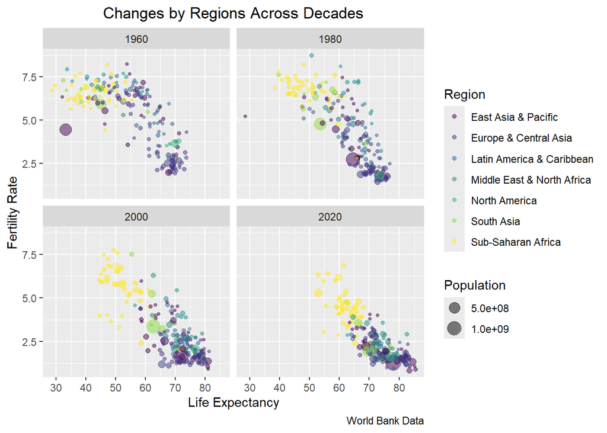

```r
#sum(is.na(wd_database3$region))

wd_database3 %>%
    filter(!is.na(region), (year == 1960 | year == 1980 | year == 2000 | year == 2020)) %>%

    ggplot(mapping = aes(x = life_exp,
                         y = fertility_rate,
                         color = region,
                         size = pop_total
                        )) +
    geom_point(alpha = 0.5) +

    scale_color_viridis_d() +

    facet_wrap( ~ year, ncol = 2) +

    xlab("Life Expectancy") +
    ylab("Fertility Rate") +

    ggtitle(label = "Changes by Regions Across Decades") +

    labs(caption = "World Bank Data", colour = "Region", size = "Population") +
    theme(plot.title = element_text(hjust = 0.5))
```

2. Interpret the plot in one sentence that address each variable.
- **Answer:** Life expectancy seems to have overall increased in the world while fertility rate decreased over the decades, while population size increased overall. Also, the richest regions have much higher life expectancy compared to the poorest regions.
7. Regional Population
1. Use only Countries (`Region` is not `NA`) to calculate the total population for each region for each year.

```r
wd_database3 %>%
  filter(!is.na(region)) %>%
  group_by(region, year) %>%
  summarise(reg_pop_tot = sum(pop_total), .groups = "drop") -> reg_pop_total
```

2. Make a line plot of calculated total population (Y) versus year (X), color-coding by region and using a *log scale* for Y. Use (`ggthemes::scale_color_colorblind`).
   - Your final plot should look like the below

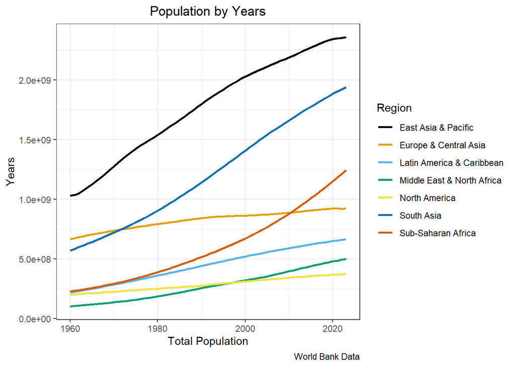

```r
reg_pop_total %>%

    ggplot(mapping = aes(x = year,
                         y = reg_pop_tot,
                         color = region)) +

    geom_line(linetype = "solid", linewidth = 1.0) +

    theme_bw() +

    scale_color_colorblind() +

    xlab("Total Population") +
    ylab("Years") +

    ggtitle(label = "Population by Years") +

    labs(caption = "World Bank Data", colour = "Region") +
    theme(plot.title = element_text(hjust = 0.5))
```